# Simulations II

Thom Volker

30-09-2020

# 1 Initial study

Loading `tidyverse`, `knitr` and `kableExtra` first, before continuing to the exercises, and set a seed for reproducibility.

## 1.1 Set seed and load packages

```r
set.seed(1)
library(tidyverse)
library(knitr)
library(kableExtra)
```

## 1.2 Simulate

Now, we create 100 samples consisting of 1000 observations from a $\mathcal{N}(0,1)$ standard normal distribution.

```r
samples <- map(1:100, function(x) rnorm(1000))
```

Additionally, we obtain the estimates from the samples such as the mean, the standard error, and the lower and upper bound of the 95% confidence interval.

```r
estimates <- function(x) {
  mu <- mean(x)
  se <- sqrt(sum((x - mu)^2) / (length(x)-1)) / sqrt(length(x))
  lower <- mu + qnorm(0.025) * se
  upper <- mu + qnorm(0.975) * se

  return(data.frame(Mean = mu, bias = abs(mu), sd = se, lower = lower, upper = upper))
}
```

We store the results in an object called results, and add the sample id for convenience. Also, we compute the coverage rate of the population mean in the sample.

```r
results <- samples %>%
  map_dfr(function(x) estimates(x), .id = "Sample")

results$Covered <- results$lower < 0 & 0 < results$upper
```

## 1.3 Visualize

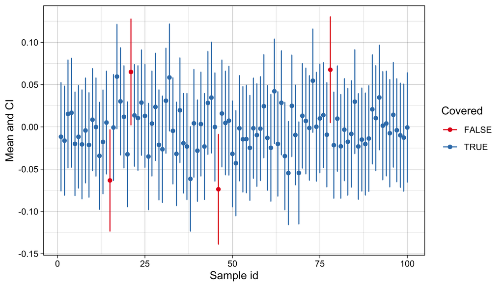

```r
ggplot(results, mapping = aes(color = Covered)) +
  geom_point(mapping = aes(x = as.numeric(Sample), y = Mean)) +
  geom_errorbar(aes(x = as.numeric(Sample), ymin = lower, ymax = upper), width = .2) +
  scale_color_brewer(palette = "Set1") +
  xlab("Sample id") +
  ylab("Mean and CI") +
  theme_linedraw()
```

## 1.4 Expose inaccurate samples

```r
results %>%
  filter(!Covered) %>%
  knitr::kable(digits = 3) %>%
  kable_styling(bootstrap_options = c("striped", "hover"),
                position = "left",
                full_width = FALSE)
```

| Sample | Mean | bias | sd | lower | upper | Covered |
| --- | --- | --- | --- | --- | --- | --- |
| 15 | -0.063 | 0.063 | 0.031 | -0.123 | -0.003 | FALSE |
| 21 | 0.065 | 0.065 | 0.032 | 0.002 | 0.128 | FALSE |
| 46 | -0.074 | 0.074 | 0.033 | -0.139 | -0.009 | FALSE |
| 78 | 0.068 | 0.068 | 0.032 | 0.005 | 0.130 | FALSE |

# 2 Replication

Now, we want to replicate the initial study, which can be done easily by doing the same thing, with a different seed. Although it is not required to set the seed manually, we still do it, so that others do not necessarily have to run both pieces of code to reproduce the results.

## 2.1 Set seed

```r
set.seed(2)
```

## 2.2 Simulate

Create 100 new samples, that differ from the previous samples.

```r
samples_v2 <- map(1:100, function(x) rnorm(1000))
```

## 2.3 Obtain the results

Fortunately, we already created a function that extracts whatever we want to know from the samples. We use this function again, and also create the coverage of every sample.

```r
results_v2 <- samples_v2 %>%
  map_dfr(function(x) estimates(x), .id = "Sample")

results_v2$Covered <- results_v2$lower < 0 & 0 < results_v2$upper
```

## 2.4 Visualize

Now, we once again visualize the samples that do not cover the population mean.

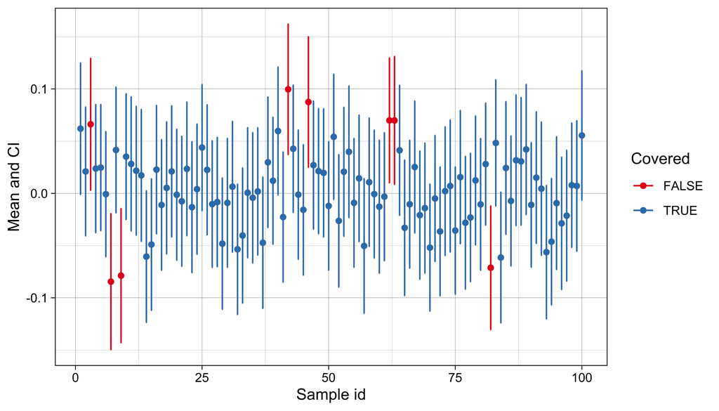

```r
ggplot(results_v2, mapping = aes(color = Covered)) +
  geom_point(mapping = aes(x = as.numeric(Sample), y = Mean)) +
  geom_errorbar(aes(x = as.numeric(Sample), ymin = lower, ymax = upper), width = .2) +
  scale_color_brewer(palette = "Set1") +
  xlab("Sample id") +
  ylab("Mean and CI") +
  theme_linedraw()
```

## 2.5 Expose inaccurate samples

And expose the results of the inaccurate samples.

```r
results_v2 %>%
  filter(!Covered) %>%
  knitr::kable(digits = 3) %>%
  kable_styling(bootstrap_options = c("striped", "hover"),
                position = "left",
                full_width = FALSE)
```

| Sample | Mean | bias | sd | lower | upper | Covered |
| --- | --- | --- | --- | --- | --- | --- |
| 3 | 0.066 | 0.066 | 0.032 | 0.003 | 0.129 | FALSE |
| 7 | -0.085 | 0.085 | 0.033 | -0.150 | -0.019 | FALSE |
| 9 | -0.079 | 0.079 | 0.033 | -0.143 | -0.015 | FALSE |
| 42 | 0.100 | 0.100 | 0.032 | 0.037 | 0.162 | FALSE |
| 46 | 0.088 | 0.088 | 0.032 | 0.025 | 0.150 | FALSE |
| 62 | 0.070 | 0.070 | 0.030 | 0.010 | 0.130 | FALSE |
| 63 | 0.070 | 0.070 | 0.031 | 0.009 | 0.131 | FALSE |
| 82 | -0.071 | 0.071 | 0.030 | -0.130 | -0.012 | FALSE |

Out of a sudden, we now see that there are 8 samples that do not cover the population mean (which may of course happen due to chance).

Have a mice day!

[figure not shown]